# Frequently asked questions

Robin Lovelace Joey Talbot and Eugeni Vidal-Tortosa, ITS Leeds

Last updated 2022-08-01

### What does CRUSE stand for?

CRUSE stands for the Cycle Route Uptake and Scenarios Estimation tool.

### What is the purpose of this tool?

The CRUSE tool will provide a web application for strategic cycle network planning across the Republic of Ireland. This involves detailed route-level visualisations of cycle journeys and a range of cycling uptake scenarios, using methods based on the [Propensity to Cycle Tool](https://www.pct.bike/) for England and Wales.

### What can the tool be used for?

The tool can be used to visualise and assess current patterns of cycling and how these could change in future, under scenarios of increased cycling uptake in Ireland. Together with local knowledge, this may provide supporting evidence to guide decisions such as where to install new cycle infrastructure, or where road safety measures may be required.

### How can I access the tool?

This is a free and open source tool, available for everyone to use.

### Which trip purposes are included in the tool?

So far we have included the following trip purposes:

- commute trips
- travel to primary school
- travel to secondary school
- travel to tertiary education
- social trips
- personal trips
- shopping trips

We do not include business trips (non-commute work-related journeys)

### What data does the tool use?

Travel to work and school is based on Central Statistics Office [POWSCAR origin-destination data](https://www.cso.ie/en/census/census2016reports/powscar/) from the 2016 Census. We use Electoral Divisions as the geographical zones between which journeys are defined.

We also include cycle journeys for other purposes including travel to public transport, leisure, shopping and touring journeys. Journey purpose data derives from from the [NTA National Household Travel Survey](https://www.nationaltransport.ie/wp-content/uploads/2020/09/National_Household_Travel_Survey_2017_Report_-_December_2018.pdf). Destination locations are assigned using [Geodirectory](https://www.geodirectory.ie/).

### How are routes calcuated? Balanced, fastest and quietest route types

Different of people have different preferences for cycle infrastructure. Children and people who are just starting the cycle may prefer off-road routes that are separated from motor traffic. Experienced cyclists who cycle to work may prefer direct routes. Everyone prefers not to mix with busy traffic but often routes are chosen based on a compromise between speed and comfort.

Planners need to be aware of different route types: ideally there should be a cohesive quiet network in place to enable beginners to start cycling safely, while it is also important to consider fast networks to ensure that cycling is the most convenient option.

The CRUSE tool accounts for different route preferences by presenting results for three types of route as shown in the figure below which shows cycling networks generated from the balanced (left), quietest (middle), and fastest (right) route types.

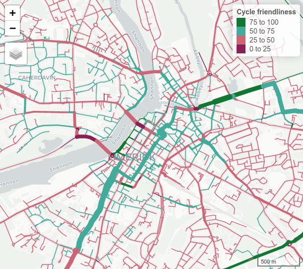

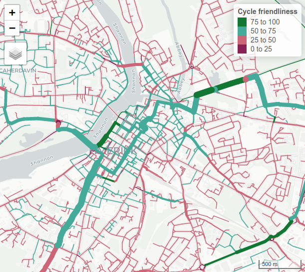

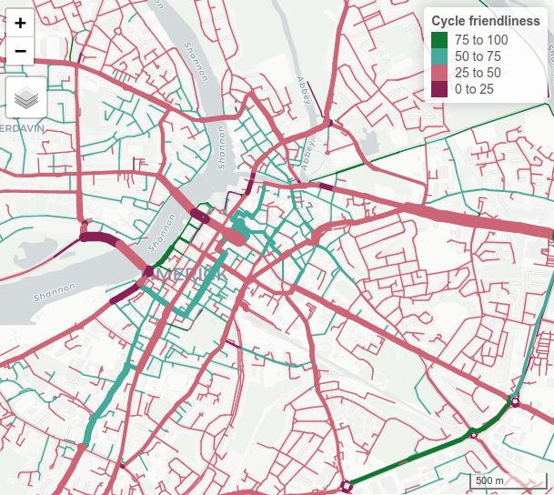

Route networks resulting from the three route types used in the CRUSE tool: balanced (the default, shown in the left hand map), quietest (middle), and fastest (right).

These route types are described below:

- *Balanced routes:* These routes balance speed and cycle friendliness. This is the default route type: balanced routes are the basis of the route network maps shown in the main page and the route prioritisation pages for each county. Balanced routes tend to err towards safety and quietness where possible and are often similar to the quietest routes.
- *Quietest routes:* These are generated with the aim of maximising cycle friendliness along the chosen route. However, they may still sometimes follow roads that are not cycle friendly, if there is no other alternative nearby. They also do not account for the impact of off road cycleways running alongside, but not on, major roads. The more separation there is between large roads and cycleways that run parallel the better from a comfort and perspective but this is not captured in the results.
- *Fastest routes:* These aim to minimise possible journey time from origin to destination. The calculation of these routes takes into account the impact of hills on journey times, but it does not take into account the cycle friendliness of the roads. Therefore the routes may follow busy main roads.

During the routing process, each journey is assigned to the road and cycle path network, from its point of origin to its destination. This aims to replicate the routes that cyclists might choose to take in real life.

We use three different route types, each developed by [CycleStreets.net](https://www.cyclestreets.net), and labelled ‘fastest’, ‘quietest’ and ‘balanced.’

### How are the number of trips determined for each trip purpose?

The POWSCAR data on travel to work and school represents the most detailed travel dataset used in the CRUSE Tool, containing accurate data on the number of trips to work, primary school, secondary school and tertiary education carried out by all modes of transport on a typical weekday. These trips from home to work or school are recorded in one direction only in the POWSCAR data, and we have followed this in the CRUSE Tool. This can be seen as representing morning peak flow. To include return journeys as part of daily trip totals, the POWSCAR flows can simply be doubled (and the same can be done for non-POWSCAR flows).

For non-POWSCAR trip purposes (including social, personal and shopping trips), we use the POWSCAR dataset as a benchmark. According to the NHTS 2017 Survey, work, business and education represent a combined total of 51% of all trips. Of these, business trips are not included in POWSCAR, and are estimated to represent around 5% of total trips (AECOM reference). Therefore, we assume that the POWSCAR data should represent 46% of total trips. We use this figure to calculate the total number of daily trips nationwide. The total number of trips for each non-POWSCAR trip purpose is calculated as a proportion of this national total. Based on this overall total, the number of non-POWSCAR trips originating from each Electoral Division is generated according to the population (aged 4 and above) of the Electoral Division.

Having obtained the origins for non-POWSCAR trips, we identify potential destinations using the Geodirectory dataset, assigning the point data to 500 m grid cells. We use a spatial interaction model to assign trips to these destinations.

There is a small difference in the way the trip purpose totals are calculated, between the POWSCAR and non-POWSCAR purposes. The POWSCAR purposes are represented as the mean daily number of one-way trips taken on a typical weekday, while the non-POWSCAR purposes are represented as the mean daily number of one-way trips averaged across the entire week, since the NHTS survey accounts for trips taken on all days of the week.

### How are the scenarios defined?

We use a number of scenarios to represent different levels of potential cycling uptake (Table 1). They are based on existing travel data using defined origin and destination points. These origins and destinations are assumed to remain the same.

In all scenarios apart from the baseline scenario, modal shares are altered to model potential future increases in cycling uptake and/or reductions in car driving. Listed in order from the lowest to the highest cycling uptake, we have created the following scenarios:

*Baseline:*

The baseline scenario uses existing modal shares for all journeys.

*Near Market:*

This scenario will be based on current cycling levels in Dublin. It thus gives an achievable level of ambition, showing what could happen if cycling uptake reaches Dublin levels (while taking account of journey length and hilliness) across the whole country. Training on Dublin data should allow cycling to reach around 8-10% mode share for trips in urban areas.

*Climate Action Plan:*

This scenario is loosely based on the Irish Government’s [Climate Action Plan 2021](https://www.gov.ie/en/publication/6223e-climate-action-plan-2021/), which contains policies for action to achieve a 51% reduction in overall greenhouse gas emissions by 2030, on a path towards net-zero by 2050. For transport, this includes 500,000 extra walking, cycling and public transport journeys per day by 2030. In terms of car travel, the target is to “Increase the proportion of kilometres driven by passenger electric cars to between 40 and 45% by 2030, in addition to a reduction of 10% in kilometres driven by the remaining internal combustion engine cars.” This equates to a 5.5 - 6% reduction in total car km driven.

To enable this decrease in car km, we model the potential for car journeys to switch to cycling, with cycling uptake increasing in line with the Go Dutch scenario. This scenario was developed for the England and Wales Propensity to Cycle Tool. There are two different versions of Go Dutch, one of which relates to travel to work, and the other to travel to school. For most trip purposes, we use the ‘travel to work’ version of Go Dutch, but for travel to primary and secondary schools, we use the ‘travel to school’ version.

In the Climate Action Plan scenario, we only allow car journeys to switch to cycling. There is no shift from other modes of transport to cycling. To be exact, for most journey purposes we only allow modal shift from car driving to cycling. Car sharing is a popular method of reducing car usage, so in many cases it’s preferable to increase the number of car passengers, if that means more car sharing instead of single occupancy journeys. However, this doesn’t work for journeys to primary and secondary schools, where school students who are given lifts by parents/guardians are recorded in the POWSCAR data as car passengers. Many of these are journeys that would not otherwise be undertaken, so they must be factored into the calculations. Therefore for primary and secondary schools, we also allow car passengers to switch to cycling.

*Go Dutch:*

In this scenario cycling reaches levels equivalent to those found in the Netherlands, taking account of the effects of route hilliness (measured as mean gradient) and route distance. Unlike in the previous two scenarios, trips can shift from any other mode to cycling, not just from cars to cycling.

As discussed above, there are two versions of Go Dutch. For trips to primary and secondary schools, we use the travel-to-school version, while for other trip purposes we use the travel-to-work version.

*Ebike:*

The Ebike scenario takes Go Dutch cycling uptake, and adds onto this the impact of increased ebike usage, which allows for longer cycle journeys. Again, trips can shift from any other mode to cycling.

However, for trips to primary and secondary schools, we use the appropriate version of Go Dutch instead (as discussed above).

Table 1 CRUSE scenarios

[output not shown]

### What is the definition of ‘Cycle friendliness’?

Cycle friendliness is a subjective measure representing the quality of a route segment (a section of road or path) for cycling. It takes into account a [range of factors](https://www.cyclestreets.net/api/v1/journey/), using data derived from OpenStreetMap. Factors that contribute to the cycle friendliness rating include (as appropriate) whether the cycleway is shared with motor vehicles or pedestrians, the type of road, presence of cycle infrastructure, speed limit, surface quality, cycle signage, any barriers or obstructions, path width and route legibility. See [CycleStreets](https://www.cyclestreets.net/help/journey/howitworks/) for further information; in this link the term ‘quietness’ is used for the same measure that we call ‘cycle friendliness’.